# ジニ指数と所得分布 - 続編

H. Suzuki

2024年1月11日

# 南部アフリカ諸国の貧困と不平等の現状

> 1月9日（火）のジニ指数の演習ファイルをもとに、1月11日（木）の講義に関係したグラフをいくつか作成し、以下に提示します。基本的に、木曜日の講義を聴きながら作成したものです。

## 世界開発指標（World Development Indicators）[[Link](https://datatopics.worldbank.org/world-development-indicators/)]

#### **貧困と不平等（Poverty and Inequality）**

**所得または消費の分配（Distribution of income or consumption）**

GINI 指数 (世界銀行推計)：SI.POV.GINI [[Link](https://data.worldbank.org/indicator/SI.POV.GINI)]

下位 10% が占める所得シェア：SI.DST.FRST.10 [[Link](https://databank.worldbank.org/metadataglossary/world-development-indicators/series/SI.DST.FRST.10)]

下位 20% が占める所得シェア：SI.DST.FRST.20 [[Link](https://databank.worldbank.org/metadataglossary/world-development-indicators/series/SI.DST.FRST.20)]

2番目の 20% が占める収入シェア：SI.DST.02ND.20 [[Link](https://databank.worldbank.org/metadataglossary/world-development-indicators/series/SI.DST.02ND.20)]

3番目の 20% が占める収入シェア ：SI.DST.03RD.20 [[Link](https://data.worldbank.org/indicator/SI.DST.03RD.20)]

4番目の 20% が占める収入シェア：SI.DST.04TH.20 [[Link](https://databank.worldbank.org/metadataglossary/world-development-indicators/series/SI.DST.04TH.20)]

上位 20% が占める収入シェア：SI.DST.05TH.20 [[Link](https://data.worldbank.org/indicator/SI.DST.05TH.20)]

上位 10% が占める収入シェア：SI.DST.10TH.10 [[Link](https://data.worldbank.org/indicator/SI.DST.10TH.10)]

## 概要を把握するための作業

### 準備

```r
library(tidyverse)
library(WDI)
library(DescTools)
```

### データの読み込み

地域情報を利用するために、`extra = TRUE` を加えました。

```r
df_gini_extra <- WDI(indicator = c(gini = "SI.POV.GINI",
                            `0-10` = "SI.DST.FRST.10",
                            `0-20` = "SI.DST.FRST.20",
                            `20-40` = "SI.DST.02ND.20",
                            `40-60` = "SI.DST.03RD.20",
                            `60-80` = "SI.DST.04TH.20",
                            `80-100` = "SI.DST.05TH.20",
                            `90-100` = "SI.DST.10TH.10"), extra = TRUE)
```

### 保存と読み込み

何度もダウンロードしなくて良いように、保存したものを読み込みます。

```r
write_csv(df_gini_extra, "data/gini_extra.csv")
```

```r
df_gini_extra <- read_csv("data/gini_extra.csv")
```

### データの確認

```r
df_gini_extra
```

| country | iso2c | iso3c | year | status | lastupdated | gini | 0-10 | 0-20 | 20-40 | 40-60 | 60-80 | 80-100 | 90-100 | region | capital | longitude | latitude | income | lending |
| --- | --- | --- | --- | --- | --- | --- | --- | --- | --- | --- | --- | --- | --- | --- | --- | --- | --- | --- | --- |
| Afghanistan | AF | AFG | 2014 | NA | 2023-12-18 | NA | NA | NA | NA | NA | NA | NA | NA | South Asia | Kabul | 69.17610 | 34.52280 | Low income | IDA |
| Afghanistan | AF | AFG | 1971 | NA | 2023-12-18 | NA | NA | NA | NA | NA | NA | NA | NA | South Asia | Kabul | 69.17610 | 34.52280 | Low income | IDA |
| Afghanistan | AF | AFG | 2006 | NA | 2023-12-18 | NA | NA | NA | NA | NA | NA | NA | NA | South Asia | Kabul | 69.17610 | 34.52280 | Low income | IDA |
| Afghanistan | AF | AFG | 2013 | NA | 2023-12-18 | NA | NA | NA | NA | NA | NA | NA | NA | South Asia | Kabul | 69.17610 | 34.52280 | Low income | IDA |
| Afghanistan | AF | AFG | 1995 | NA | 2023-12-18 | NA | NA | NA | NA | NA | NA | NA | NA | South Asia | Kabul | 69.17610 | 34.52280 | Low income | IDA |
| Afghanistan | AF | AFG | 2005 | NA | 2023-12-18 | NA | NA | NA | NA | NA | NA | NA | NA | South Asia | Kabul | 69.17610 | 34.52280 | Low income | IDA |
| Afghanistan | AF | AFG | 1997 | NA | 2023-12-18 | NA | NA | NA | NA | NA | NA | NA | NA | South Asia | Kabul | 69.17610 | 34.52280 | Low income | IDA |
| Afghanistan | AF | AFG | 1998 | NA | 2023-12-18 | NA | NA | NA | NA | NA | NA | NA | NA | South Asia | Kabul | 69.17610 | 34.52280 | Low income | IDA |
| Afghanistan | AF | AFG | 1999 | NA | 2023-12-18 | NA | NA | NA | NA | NA | NA | NA | NA | South Asia | Kabul | 69.17610 | 34.52280 | Low income | IDA |
| Afghanistan | AF | AFG | 1996 | NA | 2023-12-18 | NA | NA | NA | NA | NA | NA | NA | NA | South Asia | Kabul | 69.17610 | 34.52280 | Low income | IDA |

[output cut: 990 more lines]

### 必要な変数のみ抽出

```r
df_gini_extra <- df_gini_extra |> select(country, iso2c, year, gini:region)
```

### gini が 欠損値（NA） ではない値のもののみ表示

```r
df_gini_extra |> drop_na(gini)
```

| country | iso2c | year | gini | 0-10 | 0-20 | 20-40 | 40-60 | 60-80 | 80-100 | 90-100 | region |
| --- | --- | --- | --- | --- | --- | --- | --- | --- | --- | --- | --- |
| Albania | AL | 2002 | 31.7 | 3.5 | 8.4 | 12.6 | 16.5 | 22.2 | 40.4 | 25.4 | Europe & Central Asia |
| Albania | AL | 2005 | 30.6 | 3.5 | 8.4 | 12.9 | 17.0 | 22.5 | 39.2 | 24.3 | Europe & Central Asia |
| Albania | AL | 2008 | 30.0 | 3.7 | 8.9 | 13.1 | 16.8 | 22.2 | 39.0 | 24.5 | Europe & Central Asia |
| Albania | AL | 2014 | 34.6 | 2.9 | 7.0 | 11.5 | 16.4 | 23.3 | 41.7 | 25.5 | Europe & Central Asia |
| Albania | AL | 2015 | 32.8 | 3.2 | 7.7 | 12.1 | 16.5 | 23.0 | 40.6 | 24.8 | Europe & Central Asia |
| Albania | AL | 2016 | 33.7 | 3.0 | 7.3 | 11.8 | 16.4 | 23.2 | 41.2 | 25.0 | Europe & Central Asia |
| Albania | AL | 2017 | 33.1 | 3.1 | 7.6 | 12.0 | 16.5 | 23.3 | 40.7 | 24.6 | Europe & Central Asia |
| Albania | AL | 2018 | 30.1 | 3.2 | 7.9 | 13.0 | 17.5 | 23.3 | 38.2 | 22.7 | Europe & Central Asia |
| Albania | AL | 2019 | 30.1 | 3.5 | 8.5 | 13.0 | 17.0 | 22.7 | 38.9 | 23.6 | Europe & Central Asia |
| Albania | AL | 2020 | 29.4 | 3.4 | 8.4 | 13.2 | 17.3 | 23.0 | 38.0 | 22.8 | Europe & Central Asia |

[output cut: 990 more lines]

### gini の値の大きい順（降順）に並び替え

```r
df_gini_extra |> drop_na(gini) |>
  arrange(desc(gini)) |> distinct(country, year, gini, region)
```

| country | year | gini | region |
| --- | --- | --- | --- |
| Malawi | 1997 | 65.8 | Sub-Saharan Africa |
| South Africa | 2005 | 64.8 | Sub-Saharan Africa |
| Botswana | 2002 | 64.7 | Sub-Saharan Africa |
| South Africa | 2010 | 63.4 | Sub-Saharan Africa |
| Brazil | 1989 | 63.3 | Latin America & Caribbean |
| Namibia | 2003 | 63.3 | Sub-Saharan Africa |
| Lesotho | 1994 | 63.2 | Sub-Saharan Africa |
| South Africa | 2008 | 63.0 | Sub-Saharan Africa |
| South Africa | 2014 | 63.0 | Sub-Saharan Africa |
| Bolivia | 2000 | 61.6 | Latin America & Caribbean |

[output cut: 990 more lines]

### それぞれの国の最も新しいデータだけを取り降順に並べます

```r
df_gini_extra_recent <-df_gini_extra |> drop_na(gini) |> group_by(country) |> filter(year == max(year)) |>
  arrange(desc(gini))
df_gini_extra_recent
```

| country | iso2c | year | gini | 0-10 | 0-20 | 20-40 | 40-60 | 60-80 | 80-100 | 90-100 | region |
| --- | --- | --- | --- | --- | --- | --- | --- | --- | --- | --- | --- |
| South Africa | ZA | 2014 | 63.0 | 0.9 | 2.4 | 4.8 | 8.2 | 16.5 | 68.2 | 50.5 | Sub-Saharan Africa |
| Namibia | NA | 2015 | 59.1 | 1.0 | 2.8 | 5.8 | 9.8 | 17.9 | 63.7 | 47.3 | Sub-Saharan Africa |
| Suriname | SR | 1999 | 57.9 | NA | NA | 6.2 | 12.2 | 20.0 | 60.5 | 42.1 | Latin America & Caribbean |
| Zambia | ZM | 2015 | 55.9 | 1.1 | 3.1 | 6.3 | 10.9 | 19.4 | 60.3 | 43.5 | Sub-Saharan Africa |
| Eswatini | SZ | 2016 | 54.6 | 1.4 | 3.7 | 6.8 | 10.7 | 18.6 | 60.2 | 42.7 | Sub-Saharan Africa |
| Belize | BZ | 1999 | 53.3 | 0.9 | 3.2 | 7.7 | 12.0 | 19.4 | 57.7 | 42.4 | Latin America & Caribbean |
| Botswana | BW | 2015 | 53.3 | 1.5 | 3.9 | 7.0 | 11.1 | 19.5 | 58.5 | 41.5 | Sub-Saharan Africa |
| Brazil | BR | 2021 | 52.9 | 1.0 | 3.3 | 7.5 | 12.1 | 19.6 | 57.5 | 41.5 | Latin America & Caribbean |
| Colombia | CO | 2021 | 51.5 | 1.2 | 3.6 | 7.9 | 12.3 | 19.9 | 56.3 | 40.2 | Latin America & Caribbean |
| Angola | AO | 2018 | 51.3 | 1.3 | 3.8 | 7.7 | 12.6 | 20.4 | 55.6 | 39.6 | Sub-Saharan Africa |

[output cut: 157 more lines]

### 変形：各階級の値を縦に並べ、縦長形式の表にします。Long format

`pivot_longer(cols, names_to = "", values_to = "")` についてはいずれ説明します。ここでは、レベルに分けられたものを levels という名の列にレベルを、value という名の列に、その値を並べたものとします。

```r
df_gini_extra_long <- df_gini_extra |>
  pivot_longer(`0-10`:`90-100`, names_to = "levels", values_to = "value")
df_gini_extra_long
```

| country | iso2c | year | gini | region | levels | value |
| --- | --- | --- | --- | --- | --- | --- |
| Afghanistan | AF | 2014 | NA | South Asia | 0-10 | NA |
| Afghanistan | AF | 2014 | NA | South Asia | 0-20 | NA |
| Afghanistan | AF | 2014 | NA | South Asia | 20-40 | NA |
| Afghanistan | AF | 2014 | NA | South Asia | 40-60 | NA |
| Afghanistan | AF | 2014 | NA | South Asia | 60-80 | NA |
| Afghanistan | AF | 2014 | NA | South Asia | 80-100 | NA |
| Afghanistan | AF | 2014 | NA | South Asia | 90-100 | NA |
| Afghanistan | AF | 1971 | NA | South Asia | 0-10 | NA |
| Afghanistan | AF | 1971 | NA | South Asia | 0-20 | NA |
| Afghanistan | AF | 1971 | NA | South Asia | 20-40 | NA |

[output cut: 990 more lines]

### 日本の情報の確認

```r
df_gini_extra_long |> filter(country == "Japan") |>
  drop_na(gini) |> distinct(country, year, gini, levels, value)
```

| country | year | gini | levels | value |
| --- | --- | --- | --- | --- |
| Japan | 2010 | 32.1 | 0-10 | 3.3 |
| Japan | 2010 | 32.1 | 0-20 | 8.2 |
| Japan | 2010 | 32.1 | 20-40 | 12.7 |
| Japan | 2010 | 32.1 | 40-60 | 16.5 |
| Japan | 2010 | 32.1 | 60-80 | 22.2 |
| Japan | 2010 | 32.1 | 80-100 | 40.5 |
| Japan | 2010 | 32.1 | 90-100 | 25.7 |
| Japan | 2008 | 34.8 | 0-10 | 2.3 |
| Japan | 2008 | 34.8 | 0-20 | 6.4 |
| Japan | 2008 | 34.8 | 20-40 | 12.1 |

[output cut: 11 more lines]

```r
COUNTRIES_D <- c("Japan","United States", "South Africa")
```

```r
df_gini_extra |> select(country, year, gini:`90-100`) |> filter(country %in% COUNTRIES_D) |>
  drop_na(gini) |> group_by(country) |> filter(year == max(year))
```

| country | year | gini | 0-10 | 0-20 | 20-40 | 40-60 | 60-80 | 80-100 | 90-100 |
| --- | --- | --- | --- | --- | --- | --- | --- | --- | --- |
| Japan | 2013 | 32.9 | 2.9 | 7.7 | 12.8 | 16.6 | 21.7 | 41.1 | 26.4 |
| South Africa | 2014 | 63.0 | 0.9 | 2.4 | 4.8 | 8.2 | 16.5 | 68.2 | 50.5 |
| United States | 2021 | 39.8 | 2.2 | 6.0 | 10.6 | 15.3 | 22.1 | 46.1 | 30.1 |

### 何種類かの棒グラフで表示

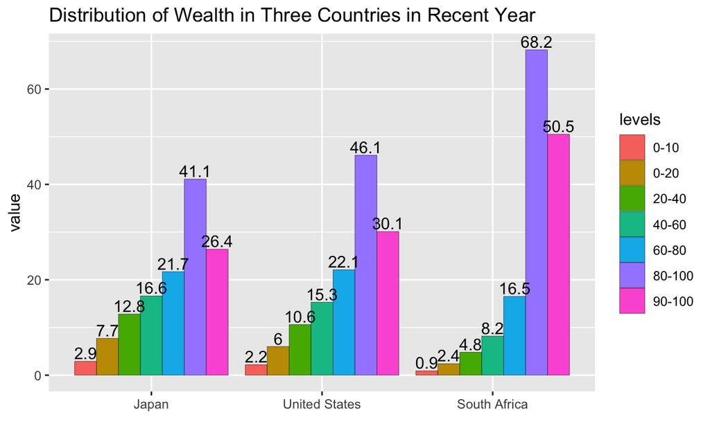

```r
df_gini_extra_long |> filter(country %in% COUNTRIES_D) |>
  drop_na(gini) |> group_by(country) |> filter(year == max(year)) |>
  ggplot(aes(factor(country, levels = COUNTRIES_D), value, fill = levels)) + geom_col(position = "dodge", col = "black", linewidth = 0.1) +
   geom_text(aes(group = levels, label = value), vjust = -0.2, position = position_dodge(width = 0.9)) +
  labs(title = "Distribution of Wealth in Three Countries in Recent Year", x = "")
```

```r
df_gini_extra_long |> filter(country %in% COUNTRIES_D) |>
  drop_na(gini) |> group_by(country) |> filter(year == max(year)) |>
  filter(!(levels %in% c('0-10','90-100'))) |>
  ggplot(aes(factor(country, levels = COUNTRIES_D), value, fill = levels)) + geom_col(position = "dodge", col = "black", linewidth = 0.1) +
   geom_text(aes(group = levels, label = value), vjust = -0.2, position = position_dodge(width = 0.9)) +
  labs(title = "Distribution of Wealth in Three Countries in Recent Year", x = "")
```

[output not shown]

**考察：0-10, 90-100 はなくても良いかもしれない。**

```r
df_gini_extra_long |> filter(country %in% COUNTRIES_D) |> filter(year == 2010) |>
  drop_na(gini) |> ggplot(aes(factor(country, levels = COUNTRIES_D), value, fill = levels)) + geom_col(position = "dodge", col = "black", linewidth = 0.1) +
   geom_text(aes(group = levels, label = value), vjust = -0.2, position = position_dodge(width = 0.9)) +
  labs(title = "Distribution of Wealth in Three Countries in 2010", x = "")
```

[output not shown]

**考察：データが限られているので、年を揃えるのは難しい。最新のデータのみを使う**

```r
df_gini_extra_long |> filter(country %in% COUNTRIES_D) |>
  drop_na(gini) |> group_by(country) |> filter(year == max(year)) |>
  filter(!(levels %in% c('0-10','90-100'))) |>
  ggplot(aes(factor(country, levels = COUNTRIES_D), value, fill = levels)) + geom_col(position = "dodge", col = "black", linewidth = 0.1) +
   geom_text(aes(group = levels, label = value), vjust = -0.2, position = position_dodge(width = 0.9)) +
  labs(title = "Distribution of Wealth in Three Countries in Recent Year", x = "")
```

### ローレンツ曲線を表示する準備

Derivation of the Lorenz curve and Gini coefficient for global income in 2011 [[リンク](https://en.wikipedia.org/wiki/Gini_coefficient)]

```r
df_gini_calc_recent <- df_gini_extra_recent |>
  mutate(`0` = 0, `10` = `0-10`, `20` = `0-20`,
         `30` = `0-20`+`20-40`/2, `40` = `0-20` + `20-40`,
         `50` = `0-20` + `20-40` + `40-60`/2,
         `60` = `0-20` + `20-40` + `40-60`,
         `70` = `0-20` + `20-40` + `40-60` + `60-80`/2,
         `80` = `0-20` + `20-40` + `40-60` + `60-80`,
         `90` = `0-20` + `20-40` + `40-60` + `60-80` + `80-100`-`90-100`,
         `100` = 100) |>
  select(-c(`0-10`:`90-100`)) # 不必要な部分を消去
df_gini_calc %>% drop_na()
```

### 縦長の Long Table に変換

```r
df_gini_calc_recent_long <- df_gini_calc_recent |>  pivot_longer(`0`:`100`, names_to = "classes", values_to = "cumulative_share") |> mutate(classes = as.numeric(classes))
df_gini_calc_long %>% drop_na()
```

### 確認

```r
df_gini_calc_recent_long |> filter(country == "Japan") |>
  ggplot() +
  geom_line(aes(classes, cumulative_share)) +
  geom_segment(aes(x = 0, y = 0, xend = 100, yend = 100), color = 'red') +
  scale_x_continuous(breaks = seq(0,100,by=20)) +
  scale_y_continuous(breaks = seq(0,100,by=20)) #+
  #annotate("text", x = 10, y = 80, label = gini)
```

## 世界の状況

### それぞれの国の最新のデータ

ジニ指数の降順

```r
df_gini_extra_recent <-df_gini_extra |> drop_na(gini) |> group_by(country) |> filter(year == max(year)) |>
  arrange(desc(gini))
df_gini_extra_recent
```

### ジニ指数の大きな30カ国を棒グラフにします

```r
top30gini <- df_gini_extra_recent |>
  arrange(desc(gini)) |> head(30) |> pull(country)
df_gini_extra_recent |> filter(country %in% top30gini) |>
  ggplot(aes(factor(country, levels = top30gini), gini, fill = region)) + geom_col() +
  theme(axis.text.x = element_text(angle = 90, vjust = 1, hjust=1), legend.position = "top") +
  labs(title = "Top 30 Countries of Recent Gini Index", x = "")
```

[output not shown]

**考察：二地域に限られています**

### 分布を地域ごとの箱ひげ図で見てみます

箱ひげ図とは？ [[リンク](https://bellcurve.jp/statistics/course/5219.html)]

```r
df_gini_extra_recent |> drop_na(region) |> filter(region != "Aggregates") |>
  ggplot(aes(gini, region, fill = region)) + geom_boxplot() +
  theme(legend.position = "")
```

## 南アフリカ５カ国について

```r
SOUTH_AFRICA_FIVE <- c("South Africa", "Namibia", "Eswatini", "Botswana", "Lesotho")
```

### 経年変化を表す折れ線グラフ

```r
df_gini_extra |> filter(country %in% SOUTH_AFRICA_FIVE ) |>
  drop_na(gini) |>
  ggplot(aes(year, gini, col = factor(country, level = SOUTH_AFRICA_FIVE))) +
  geom_line() + labs(title = "Gini Index of Five Countries", col = "From gini top")
```

```r
df_gini_extra_long |> filter(country %in% SOUTH_AFRICA_FIVE ) |>
  drop_na(value) |>
  ggplot(aes(year, value, col = levels)) + geom_line() + facet_wrap(~factor(country, level = SOUTH_AFRICA_FIVE)) + labs(title = "Change of ratio of each level")
```

[output not shown]

早くからデータがある国のジニ指数が低いように見える

### 最新のデータ

データの数も少ないので、最新のデータのみに限る

```r
df_gini_extra_recent |> filter(country %in% SOUTH_AFRICA_FIVE)
```

`SOUTH_AFRICA_FIVE` の国の順番を、Gini 指数の大きい順に並べておく

### ローレンツ曲線

```r
df_gini_calc_recent_long |> filter(country %in% SOUTH_AFRICA_FIVE) |>
  ggplot() +
  geom_line(aes(classes, cumulative_share, col = factor(country, levels = SOUTH_AFRICA_FIVE))) +
  geom_segment(aes(x = 0, y = 0, xend = 100, yend = 100, col = country), color = 'red') +
  scale_x_continuous(breaks = seq(0,100,by=20)) +
  scale_y_continuous(breaks = seq(0,100,by=20)) +
  labs(col = "From gini top")
```

### 所得の割合を表す棒グラフ

```r
df_gini_extra_long |> filter(country %in% SOUTH_AFRICA_FIVE) |>
  drop_na(gini) |> group_by(country) |> filter(year == max(year)) |>
  filter(!(levels %in% c('0-10','90-100'))) |>
  ggplot(aes(factor(country, levels = SOUTH_AFRICA_FIVE), value, fill = levels)) + geom_col(position = "dodge", col = "black", linewidth = 0.1) +
   geom_text(aes(group = levels, label = value), vjust = -0.2, position = position_dodge(width = 0.9)) +
  labs(title = "Distribution of Wealth in Five Countries in Recent Year", x = "")
```

### ジニ指数と Top 20% の値の相関

```r
df_gini_extra_recent |> filter(region != "Aggregates") |> drop_na(`80-100`) |>
  ggplot(aes(gini, `80-100`)) + geom_point(aes(col = region)) +
  geom_smooth(formula = 'y ~ x', method = "lm")
```

[output not shown]

**考察**：かなり強い正の相関があり、回帰直線がかなり適合している。

## 練習： 国のリストを変えてみよう

### 国の選択

```r
CHOSEN_GINI_COUNTRIES <- c("Suriname", "Belize", "Brazil", "Colombia")
```

### 経年変化を表す折れ線グラフ

```r
df_gini_extra |> filter(country %in% CHOSEN_GINI_COUNTRIES) |>
  drop_na(gini) |>
  ggplot(aes(year, gini, col = factor(country, level = CHOSEN_GINI_COUNTRIES))) +
  geom_line() + labs(title = "Gini Index of Chosen Countries", col = "From gini top")
```

```r
df_gini_extra_long |> filter(country %in% CHOSEN_GINI_COUNTRIES) |>
  drop_na(value) |>
  ggplot(aes(year, value, col = levels)) + geom_line() + facet_wrap(~factor(country, level = CHOSEN_GINI_COUNTRIES)) + labs(title = "Change of ratio of each level")
```

**考察：**

### 最新のデータ

データの数も少ないので、最新のデータのみに限る

```r
df_gini_extra_recent |> filter(country %in% CHOSEN_GINI_COUNTRIES)
```

**考察：**

`CHOSEN_GINI_COUNTRIES` の国の順番を、Gini 指数の大きい順に並べておく

### ローレンツ曲線

```r
df_gini_calc_recent_long |> filter(country %in% CHOSEN_GINI_COUNTRIES) |>
  ggplot() +
  geom_line(aes(classes, cumulative_share, col = factor(country, levels = CHOSEN_GINI_COUNTRIES))) +
  geom_segment(aes(x = 0, y = 0, xend = 100, yend = 100, col = country), color = 'red') +
  scale_x_continuous(breaks = seq(0,100,by=20)) +
  scale_y_continuous(breaks = seq(0,100,by=20)) +
  labs(col = "From top gini")
```

**考察：**

### 所得の割合を表す棒グラフ

```r
df_gini_extra_long |> filter(country %in% CHOSEN_GINI_COUNTRIES) |>
  drop_na(gini) |> group_by(country) |> filter(year == max(year)) |>
  filter(!(levels %in% c('0-10','90-100'))) |> drop_na(value) |>
  ggplot(aes(factor(country, levels = CHOSEN_GINI_COUNTRIES), value, fill = levels)) + geom_col(position = "dodge", col = "black", linewidth = 0.1) +
   geom_text(aes(group = levels, label = value), vjust = -0.2, position = position_dodge(width = 0.9)) +
  labs(title = "Distribution of Wealth in Chosen Countries in Recent Year", x = "")
```

**考察：**